# Introduction to Hight Throughtput Experiment Data Analysis

07/22/2018

## High through-put experiments

High through-put experiment (HTE) uses approaches such as sequencing techonology, Mass Spectrometry based analytical chemistry methods to study the quality or quantity of a large number of features such as nucleic acid sequences, proteins, small molecules, or other features in biological or enviromental specimens, or study subjects.

[interactive chart not shown]

## Biology and Data Science

Data science is an interdisciplinary field that uses scientific methods, processes, algorithms and systems to extract knowledge and insights from data in various forms.

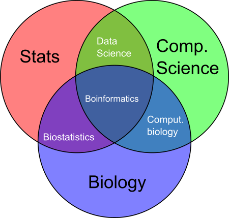

Bioinformatics venn

## High Through-put Experiment Data

- The starting point of a high through-put experiment is usually raw sequencing data.
- fastq files for microbiome, metagenomics, RNA seq, etc
- mzML/mzXML MS files for proteomics (and **maybe** metabolomics)

[interactive chart not shown]

## Data Processing and Analysis

- Should be standardized, clear and reproducible.
- High through-put experiments data processing is the assay- or experiment-dependent, but not study dependent. The data processing precedure doesn’t change with the study design.
- Proteomics: X!Tandem
- 16S-seq: fastq-multx, cutadapt/trimmomatic/fastx-toolkit, DADA2
- After we generate the tabular data from data processing, the data analysis step is study dependent. Different statistic model and visualization approaches can be used base on the study design.

## Basic Principle of Data Science

- Principle of tidy data
- Reproducibility
- Why R
- Version Control (git)
- Data structure of hight through-put experiment data

## Tidy Data

1. Each measured variable should be in one column.
2. Each different observation of that variable should be in a different row.
3. There should be one table for each “kind” of variable.
4. If you have multiple tables, they should include a column in the table that allows them to be linked.

## Tidy Data continue

1. Each measured variable should be in one column.
2. Each different observation of that variable should be in a different row.

[interactive chart not shown]

## Messy Data Example

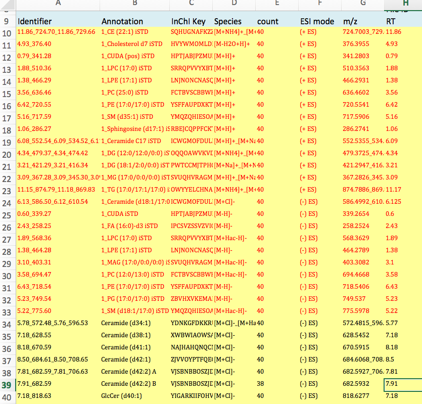

lipidome-messy

## Reproducibility

- The raw data should be stored well and every analysis step should be documented.
- Reproducibility allows you to be validate you analysis, and collaborate with other people.
- Using programming language is the best way to make your analysis reproducible.
  - SAS
  - R
  - Python
  - Julia

## Why R

- R is a programming language designed for statistics and data analysis. R’s native packages can support almost all basic statistics test (linear model, t test, correlation, etc).
- R has tremendous amount of additional packages on [CRAN](https://cran.r-project.org/) that extend the functionality of R for almost all fields (ecology, chemistry, engineering, etc.)
- The [bioconductor](https://www.bioconductor.org) project has also a lot of packages designated for bioinformatics, contributed by scientists all over the world.
- Very popular in academic community.
- Almost all R packages have very detailed documentations
- Ability to generate scientific report/presentations in different forms, including html, pdf, slides, and word docx.

## Why R cont.

R is also a good choice for a career!

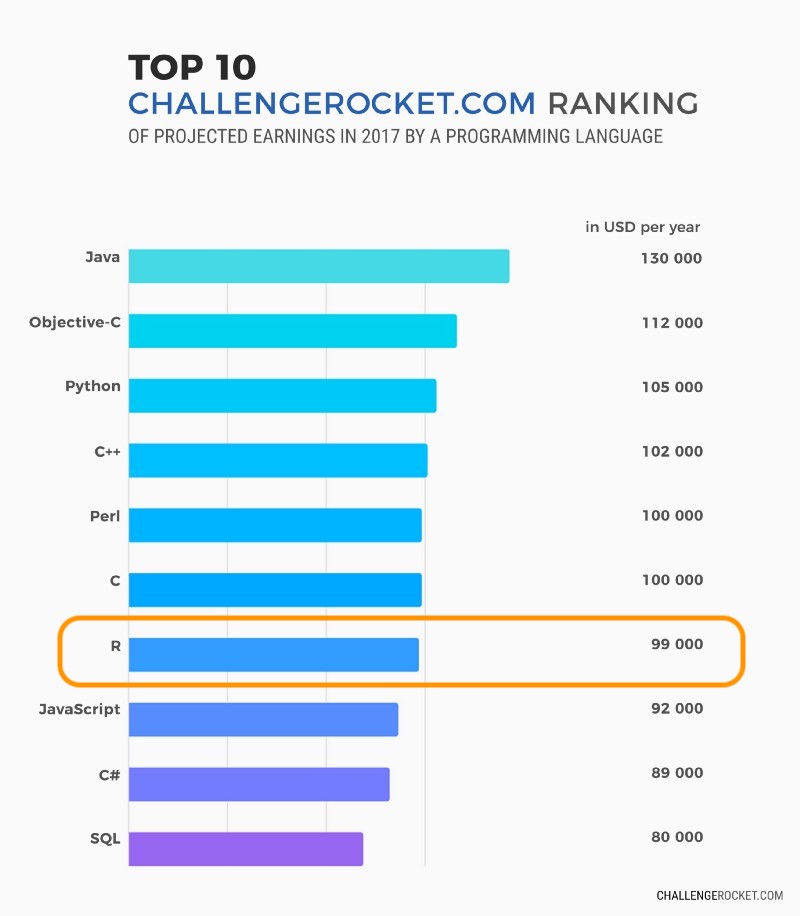

## Version control

- Git: a distributed version control system
- Github, a web-based hosting service for git
  - Pros:
    - Use as a static html service
    - Multiple people can work on the same project
  - Cons:
    - Public to the world unless you pay
    - Single file size limit

## Metabase

- The Metabase is a R pacakge provides a solution to store, handle, analyze, and visualize data from quantitative experiments such as metabolomics and proteomics.
- Now only the metabolomics data is well embeded, but theoretically it’s able to support any quantitative experiment data, including metabolomics, proteomics, glycomics, nutrient data, anthropometric and clinical data, biochemical assays.
- github repo: github.com/zhuchcn/Metabase

## Hight Thoughput Experiment Data Structure

Almost all high thoughput experiment data have 3 tables:

- A table with information to each feature (pink box)
- A table with information to each sample (blue box)
- A pure numeric table of the intensity/concentration/abundance of each feature in each sample (gree box)

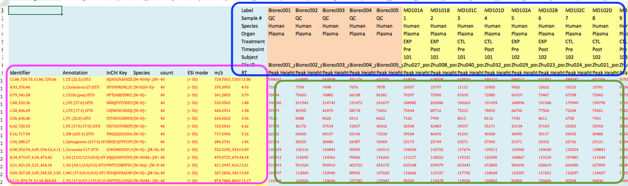

## Metabase Design

- The Metabase uses the **Object Oriented Design**.

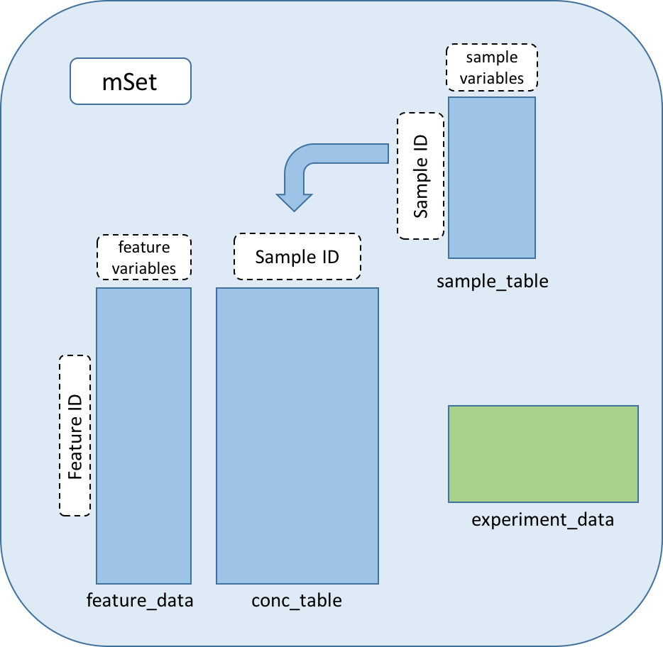

Metabase Design

## Classes Roadmap

Only MetabolomicsSet, LipidomicsSet and MultiSet are available now. ProteomicsSet and GLycomicsSet are not done yet.

*Collabration is very welcome!*

[interactive chart not shown]

## Documentation

www.chenghaozhu.net